# Kolleg Europa - Network Analysis

Datenaufbereitung

Stefan Haussner

6 März 2019

In diesem Fall muss das Netzwerk aus einer edge list einglesen werden. Das ist gerade bei größeren Netzwerken üblich und spart Platz gegenüber einer incidence matrix.

# Schritt 1: Einlesen der Excel-Datei und Preprocessing für igraph

- Offizielle Position des Besuchers:
  - Character-Einträge werden umgewandelt in numeric
  - Prime Minister als 1
  - Secretary General als 2
  - alles andere als 3 (und vermutlich später ausgefiltert, weil 3 eigentlich nicht vorgesehen)
- Offizielle Position des Gastes
  - Gleiches wie bei Offizieller Position des Besuchers
  - Vice President ist wie Außenminister
  - bei den Fällen, wo mehrere getroffen wurden, wird NUR der erste Gastgeber gewertet
- Gast-Gastgeber-Verhältnis (GuestHost_rltnshp)
  - beide Partner Regierungschef –> 1
  - beide Partner Außenminister –> 2
  - ein Partner Regierungschef –> 3
  - andere –> 4

```r
rd_raw <- openxlsx::read.xlsx("../data/Reisediplomatie Projekt_fin.xlsx", sheet = 1, na.strings = ".", detectDates = TRUE) %>%
  as_tibble() %>%
  janitor::clean_names()


rd_clean <- rd_raw %>%
  rename(OffPos_Gast = offizielle_position_des_besuchers_1_regierungschef_in_2_aussenminister_in,
         OffPos_Host = offizielle_position_des_der_gesprachspartners_in_im_gastland_1_regierungschef_in_2_aussenminister_in_3_sonstiges_angeben) %>%
  mutate(OffPos_Gast = case_when(OffPos_Gast == "Prime Minister" ~ "1",
                            OffPos_Gast == "Secretary General" ~ "2",
                            OffPos_Gast == "President" ~ "1",
                            OffPos_Gast == "Secretary of State" ~ "2",
                            OffPos_Gast == "State Minister of Foreign Affairs" ~ "2",
                            OffPos_Gast == "1" ~ "1",
                            OffPos_Gast == "2" ~ "2",
                            TRUE ~ "3"),
         OffPos_Host = case_when(OffPos_Host == "Prime Minister" ~ "1",
                            OffPos_Host == "Secretary General" ~ "2",
                            OffPos_Host == "President" ~ "1",
                            OffPos_Host == "Secretary of State" ~ "2",
                            OffPos_Host == "State Minister of Foreign Affairs" ~ "2",
                            OffPos_Host == "Vice President" ~ "2",
                            OffPos_Host == "1" ~ "1",
                            OffPos_Host == "2" ~ "2",
                            TRUE ~ OffPos_Host),
         OffPos_Host = stringr::str_sub(OffPos_Host,1,1),
         OffPos_Host = case_when(OffPos_Host == "1" | OffPos_Host == "2" | OffPos_Host == "3" ~ OffPos_Host,
                                 OffPos_Host %in% c("U","C","M","G","F") ~ "3",
                                 TRUE ~ NA_character_),
         gastland = case_when(gastland == "Isreal" ~ "Israel",
                              TRUE ~ gastland)
         ) %>%
  mutate(OffPos_Gast = as.numeric(OffPos_Gast),
         OffPos_Host = as.numeric(OffPos_Host)) %>%
  mutate(GuestHost_rltnshp = case_when(OffPos_Gast == 1 & OffPos_Host == 1 ~ 1,
                                       OffPos_Gast == 2 & OffPos_Host == 2 ~ 2,
                                       xor(OffPos_Gast == 1, OffPos_Host == 1) ~ 3,
                                       TRUE ~ 4),
         iso3_eu = countrycode(eu_land, "country.name.de", "iso3c"),
         iso3_host = countrycode(gastland, "country.name.de", "iso3c"))
```

Datensatz so auswählen, dass nur die wirklichen Verbindungen da sind. Gefiltert werden alle NAs (die müssen vorher geregelt werden), alle Gastländer die gleichzeitig EU-Länder sind (sonst kein bipartites Netz). Wenn auch EU-Länder als Gastländer auftreten sollen, ändert sich die Art des Netzwerks.

> Hier sind zwei Entscheidungsfragen drin, die noch geklärt werden müssen.

```r
eu28 <- data.frame(codelist$iso3c,codelist$eu28) %>%
  filter(!is.na(codelist.eu28)) %>%
  .$codelist.iso3c %>%
  as.vector()

rd_pregraph <- rd_clean %>%
  filter(!is.na(iso3_host)) %>%
  filter(!(iso3_host %in% eu28))


rd_ready <- rd_pregraph %>%
  select(iso3_eu, iso3_host)
```

# Schritt 2: Creating Affiliation Network from Edge List

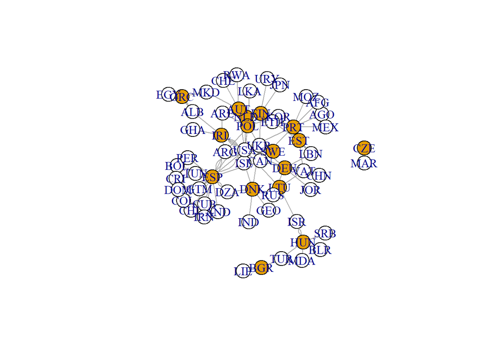

```r
rd_igraph <- rd_ready %>% graph.data.frame(directed = FALSE)


V(rd_igraph)$type <- V(rd_igraph)$name %in% as.data.frame(rd_ready)[,1]

plot.igraph(rd_igraph, vertex.color = V(rd_igraph)$type)
```

# Schritt 3: Hinzufügen von zusätzlichen Attributen

Bisher hinzugefügt: * offizielle Position des Gastes * Gast-Gastgeber-Verhältnis

```r
E(rd_igraph)$GastPos <- rd_pregraph$OffPos_Gast
E(rd_igraph)$GastHost <- rd_pregraph$GuestHost_rltnshp
```

# Speichern des Workspace von produzierten Datensätzen:

```r
save(list = ls(), file = "../data/data_preprocessed.Rdata")
```